# Grizzly Bear Population Status Indicator

## Threats to Grizzly Bears

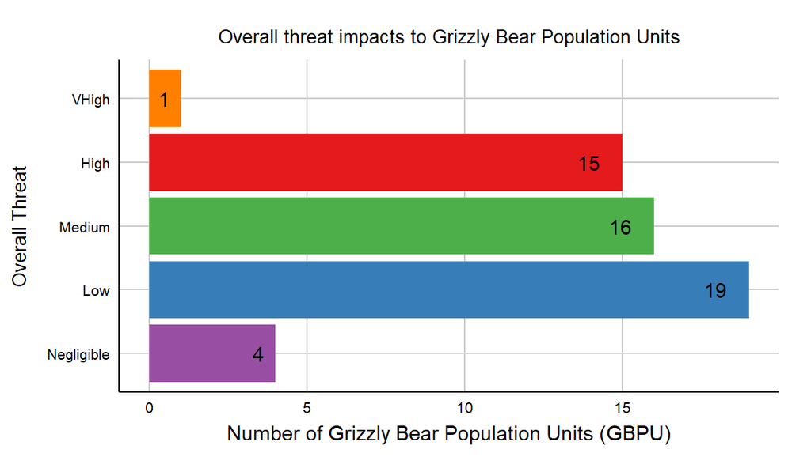

The largest number of threats was due to Human Intrusion , followed by transportation (road and rail density), energy production and mining, agriculture (livestock density), residential (human density), biological resource use (mortality), and climate-change (salmon decline).

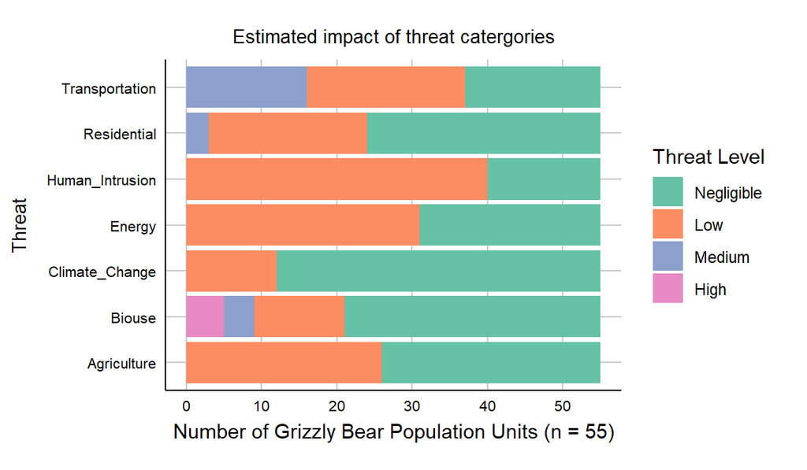

## Management Ranks

Across the province 17 GBPU are ranked as highest concern (M1-2), 14 as moderate concern (M3-4) and 24 as lowest concern (M4-5). In general GBPUs located in the southern portion of the province were of higher concern. GBPU units adjacent to the Central Interior unit, in which grizzly bears have been extirpated, were also ranked higher.

Identifying management status at the population unit can be used to priorities action where the management concerns are highest. Detailed threat information identified for each unit will also help to direct management actions for localised threats identified within the unit.

## Methods

We used internationally recognized methodology, developed by NatureServe <sup>2</sup> to ensure ranks were assigned in line with international standards on species management criteria (NatureServe and international ranking (IUCN).

The threats are based on the IUCN-CMP (Conservation Measures Partnership) classifications of direct threats . To document the steps for ranking species or ecosystems NatureServe uses an ‘Element Rank Calculator[http://www.natureserve.org/conservation-tools/conservation-rank-calculator] . The calculator includes a summary of the IUCN threats to species13, as well as, population size, trend and other criteria based on standardized ranking methods12.

The Nature Serve calculator uses the 11 IUCN threat categories to determine impacts to species (residential and commercial development, agriculture and aqua- culture, energy production and mining, transportation and service corridors, biological resource use, human intrusions and disturbance, natural system modifications, invasives and other problematic species and genes, pollution, geological events, climate change and severe weather). Threat categories are based on threat scope and severity. The NatureServe calculator then combines the individual threats to determine an overall threat category. Appendix 5 in British Columbia’s Guide to Recovery Planning for Species and Ecosystems presents a full description of NatureServe threat assignment using threat scope, severity, and timing.

Each GBPU starts with a rank of 5 – M5 no conservation concern – this value is reduced based on 1) negative population trend, 2) small and/or isolated population, and 3) overall threat (negligible, low, medium, high & very high)

## References and Other Useful Links

<sup>2</sup> NatureServe. 2015. NatureServe Element Occurrence Viability Calculator Version 1. NatureServe, Arlington, VA.

[British Columbia conservation Foundation’s Bear Aware Program] (https://wildsafebc.com/grizzly-bear/)

## Data

*By accessing these datasets, you agree to the licence associated with each file, as indicated in parentheses below.

- [Indicator data: BC Grizzly Bear Habitat Classification and Rating](https://catalogue.data.gov.bc.ca/dataset/bc-grizzly-bear-habitat-classification-and-rating)

Published and Available On-Line at Environmental Reporting BC (August 2019):  
http://www.env.gov.bc.ca/soe/indicators/plants-and-animals/grizzly-bears.html

Email correspondence to: envreportbc@gov.bc.ca

*Suggested Citation*:  
Environmental Reporting BC. 2019. Grizzly Bear Population Status in B.C. State of Environment Reporting, Ministry of Environment and Climate Change Strategy, British Columbia, Canada.